# Sales Analysis and Forecasting

Abhijith

2024-10-18

# Sales Prediction Analysis

## 1. Introduction

This report presents an analysis of sales data and the development of forecasting models to predict future sales. We’ll explore the dataset, perform exploratory data analysis, and compare different forecasting models to determine the most effective approach for predicting sales.

## 2. Loading Dataset

First, we’ll load the necessary libraries and the dataset.

```r
library(tidyverse)
library(lubridate)
library(ggplot2)
library(forecast)
library(randomForest)
library(xgboost)
library(readr)
library(dplyr)
library(randomForest)
library(xgboost)
library(stats)
library(stringr)
library(forecast)
library(gridExtra)

# Load the dataset
train_data <- read.csv("train.csv")
```

## 3. Data Exploration

Let’s take a look at the structure and summary of our dataset.

```r
str(train_data)
```

```
## 'data.frame':    913000 obs. of  4 variables:
##  $ date : chr  "2013-01-01" "2013-01-02" "2013-01-03" "2013-01-04" ...
##  $ store: int  1 1 1 1 1 1 1 1 1 1 ...
##  $ item : int  1 1 1 1 1 1 1 1 1 1 ...
##  $ sales: int  13 11 14 13 10 12 10 9 12 9 ...
```

```r
summary(train_data$sales)
```

```
##    Min. 1st Qu.  Median    Mean 3rd Qu.    Max.
##    0.00   30.00   47.00   52.25   70.00  231.00
```

## 4. Exploratory Data Analysis

Now, we’ll visualize the sales data to understand patterns and trends.

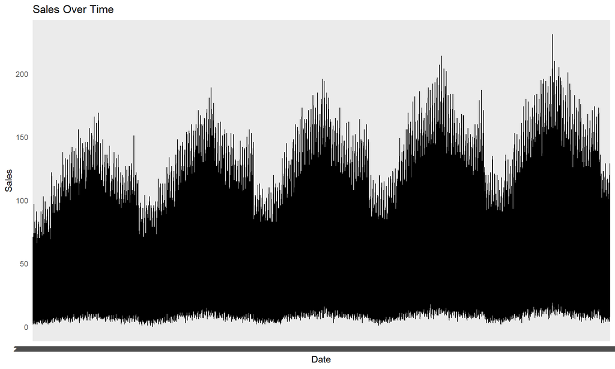

```r
# Plot sales over time
ggplot(train_data, aes(x = date, y = sales)) +
  geom_line() +
  theme_minimal() +
  labs(title = "Sales Over Time", x = "Date", y = "Sales")
```

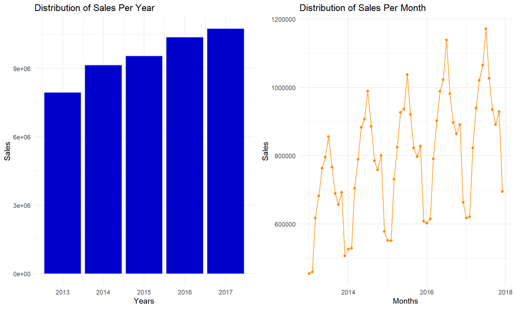

```r
# Function to aggregate sales by month or year
monthlyORyears_sales <- function(data, time = c("monthly", "years")) {
  data %>%
    mutate(date = as.Date(date)) %>%
    group_by(date = if(time == "monthly") floor_date(date, "month") else floor_date(date, "year")) %>%
    summarise(sales = sum(sales, na.rm = TRUE)) %>%
    ungroup()
}

# Monthly and yearly sales
m_df <- monthlyORyears_sales(train_data, "monthly")
y_df <- monthlyORyears_sales(train_data, "years")

# Plot yearly and monthly sales
p1 <- ggplot(y_df, aes(x = date, y = sales)) +
  geom_bar(stat = "identity", fill = "mediumblue") +
  labs(title = "Distribution of Sales Per Year", x = "Years", y = "Sales") +
  theme_minimal()

p2 <- ggplot(m_df, aes(x = date, y = sales)) +
  geom_line(color = "darkorange") +
  geom_point(color = "darkorange") +
  labs(title = "Distribution of Sales Per Month", x = "Months", y = "Sales") +
  theme_minimal()

grid.arrange(p1, p2, ncol = 2)
```

## 5. Train and Test Split

```r
# For yearly models
yearly_sales <- train_data %>%
  mutate(year = year(as.Date(date))) %>%
  group_by(year) %>%
  summarise(total_sales = sum(sales)) %>%
  filter(year >= 2013 & year <= 2018)

# For monthly models
monthly_sales <- train_data %>%
  mutate(date = as.Date(date)) %>%
  filter(year(date) >= 2013 & year(date) <= 2018) %>%
  group_by(date = floor_date(date, "month")) %>%
  summarise(total_sales = sum(sales))

# Convert to time series object for ARIMA and SARIMA
sales_ts <- ts(monthly_sales$total_sales, start = c(2013, 1), frequency = 12)
```

## 6. Forecasting Models

We’ll implement and evaluate several forecasting models:

1. Random Forest
2. XGBoost
3. Linear Regression
4. ARIMA
5. SARIMA

### 6.1 Random Forest

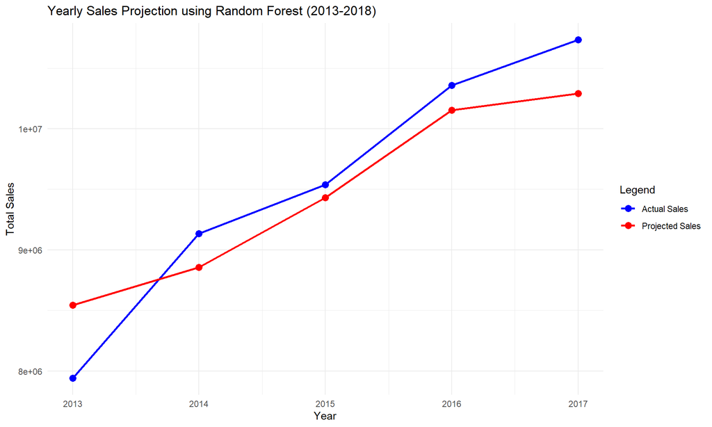

```r
rf_model <- randomForest(total_sales ~ year, data = yearly_sales, ntree = 500)
rf_predictions <- predict(rf_model, newdata = data.frame(year = yearly_sales$year))

ggplot(yearly_sales, aes(x = year)) +
  geom_line(aes(y = total_sales, color = "Actual Sales"), size = 1) +
  geom_line(aes(y = rf_predictions, color = "Projected Sales"), size = 1) +
  geom_point(aes(y = total_sales, color = "Actual Sales"), size = 3) +
  geom_point(aes(y = rf_predictions, color = "Projected Sales"), size = 3) +
  scale_color_manual(values = c("Actual Sales" = "blue", "Projected Sales" = "red")) +
  labs(title = "Yearly Sales Projection using Random Forest (2013-2018)",
       x = "Year", y = "Total Sales", color = "Legend") +
  theme_minimal()
```

### 6.2 XGBoost

```r
dtrain <- xgb.DMatrix(data = as.matrix(yearly_sales["year"]), label = yearly_sales$total_sales)
params <- list(objective = "reg:squarederror", eta = 0.1, max_depth = 3, nrounds = 100)
xgb_model <- xgb.train(params = params, data = dtrain, nrounds = 100)
```

```
## [21:24:41] WARNING: src/learner.cc:767:
## Parameters: { "nrounds" } are not used.
```

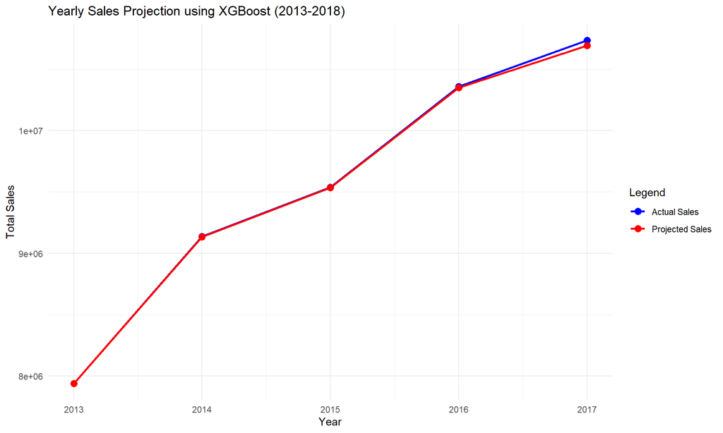

```r
xgb_predictions <- predict(xgb_model, as.matrix(yearly_sales["year"]))

ggplot(yearly_sales, aes(x = year)) +
  geom_line(aes(y = total_sales, color = "Actual Sales"), size = 1) +
  geom_line(aes(y = xgb_predictions, color = "Projected Sales"), size = 1) +
  geom_point(aes(y = total_sales, color = "Actual Sales"), size = 3) +
  geom_point(aes(y = xgb_predictions, color = "Projected Sales"), size = 3) +
  scale_color_manual(values = c("Actual Sales" = "blue", "Projected Sales" = "red")) +
  labs(title = "Yearly Sales Projection using XGBoost (2013-2018)",
       x = "Year", y = "Total Sales", color = "Legend") +
  theme_minimal()
```

### 6.3 Linear Regression

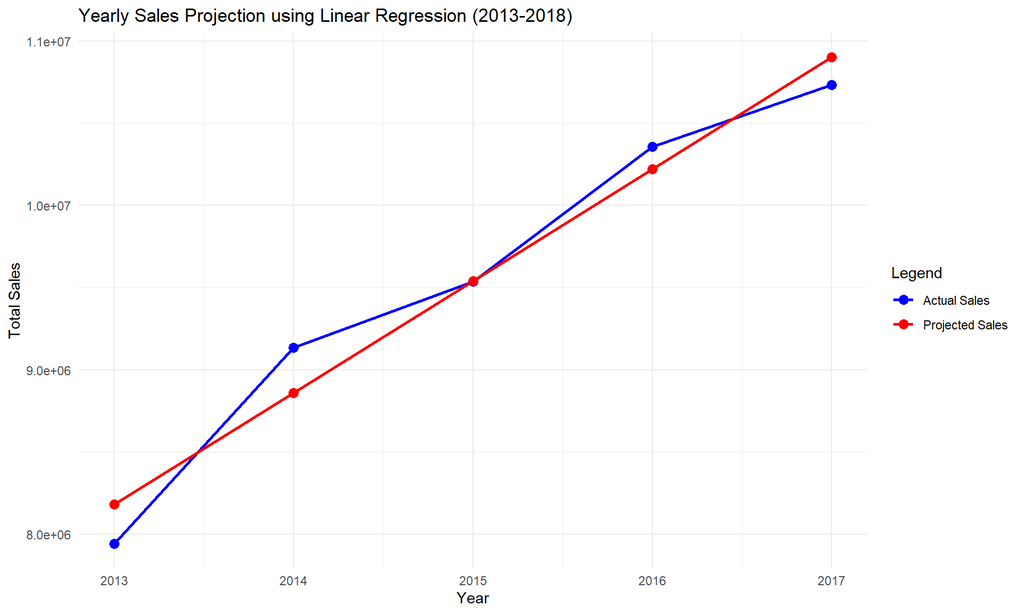

```r
lm_model <- lm(total_sales ~ year, data = yearly_sales)
lm_predictions <- predict(lm_model, newdata = yearly_sales)

ggplot(yearly_sales, aes(x = year)) +
  geom_line(aes(y = total_sales, color = "Actual Sales"), size = 1) +
  geom_line(aes(y = lm_predictions, color = "Projected Sales"), size = 1) +
  geom_point(aes(y = total_sales, color = "Actual Sales"), size = 3) +
  geom_point(aes(y = lm_predictions, color = "Projected Sales"), size = 3) +
  scale_color_manual(values = c("Actual Sales" = "blue", "Projected Sales" = "red")) +
  labs(title = "Yearly Sales Projection using Linear Regression (2013-2018)",
       x = "Year", y = "Total Sales", color = "Legend") +
  theme_minimal()
```

### 6.4 ARIMA

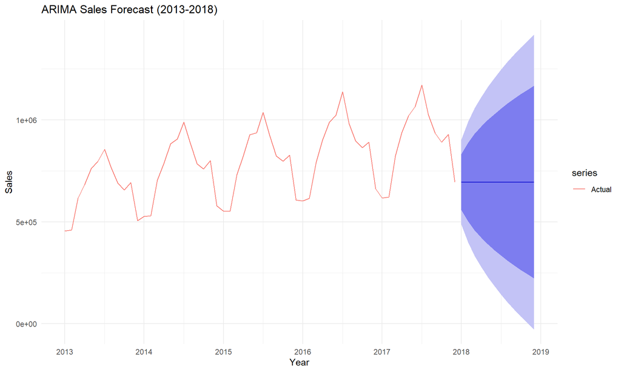

```r
arima_model <- auto.arima(sales_ts, seasonal = FALSE)
arima_forecast <- forecast(arima_model, h = 12)

autoplot(arima_forecast) +
  autolayer(sales_ts, series = "Actual") +
  labs(title = "ARIMA Sales Forecast (2013-2018)", y = "Sales", x = "Year") +
  theme_minimal()
```